# 热工基础 · 第 5 讲：导热

刘训臣

山东科技大学 机械电子工程学院

# 第〇部分 · 课程介绍与本讲定位

## 第 5 讲：教学内容与主线

> **一条主线：热量怎么”走”——从随机行走出发，建立导热问题的完整框架。**
- 三种传热方式：导热、热对流、热辐射（机理与区别）
- **随机行走 → 扩散方程**：微观无序 ⟶ 宏观 Gaussian
- 三类扩散统一：质量（Fick）/ 动量（牛顿黏性）/ 热量（Fourier）——同一套数学
- **Fourier 定律与热扩散方程**：$q=-\lambda\nabla T$、$\partial T/\partial t=a\nabla^2T$、三类边界条件
- **稳态导热**：平壁 / 圆筒壁 / 球壁 + 热阻串联 + 临界绝缘直径 + 肋片
- **非稳态导热简介**：$Bi$、$Fo$、集总参数法
- 真题 + 算例 + 作业

> 一句话：**前四讲是热力学（平衡态、过程、循环），从本讲起进入传热学（温度场如何演化）。**

## 本讲定位：从热力学到传热学

**前四讲做了什么**（热力学）：平衡态、四大公理、基本方程、理想气体、热力过程与 Carnot 循环——回答”能不能发生、最终到哪”。

**从本讲开始**（传热学）：回答”**多快、怎么走**”——温度场随空间与时间如何演化。

- 传热学的三块：**导热**（本讲）、**对流换热**（第 6 次课）、**热辐射**（第 7 次课）
- 本讲的工具：随机行走模型（微观）→ 扩散方程（宏观）→ Fourier 定律（本构）→ 热阻网络（工程）
- 三种传热方式的判别是历年真题送分点（见第五部分）

**推导留给 AI**：① 问他”为什么热力学不能回答’传热多快’“（提示：热力学只管初末态，不含时间与空间梯度）；② 让他举例：暖气片散热同时包含哪三种传热方式。

# 第一部分 · 传热机理与三类扩散

- 三种传热方式：导热、热对流、热辐射
- 随机行走：微观无序 ⟶ 宏观 Gaussian
- 扩散方程：时间一阶导 ∝ 空间二阶导
- 三类扩散统一：质量 / 动量 / 热量

## 三种传热方式总览

**三种基本传热方式的机理**：

| 方式 | 机理 | 需介质？ | 例子 |
| --- | --- | --- | --- |
| **导热** | 分子热运动与碰撞（能量逐层传递） | 需要 | 固体杆导热、平壁 |
| **热对流** | 流体宏观运动携带热量 | 需要（流体） | 暖气片对流、风冷 |
| **热辐射** | 电磁波（光子）发射与吸收 | **不需要** | 太阳辐射、炉膛辐射 |

- 三种方式**往往同时出现**（如暖气片：导热 + 对流 + 辐射），实际传热多为复合过程
- 本讲只讲**导热**；对流与辐射分别在后面两讲

**推导留给 AI**：① 问他三种方式的”传递载体”各是什么；② 让 AI 举出三个”两种及以上方式同时作用”的日常例子并说明各占多少（量级即可）。

## 随机行走：从微观涨落到宏观分布

- 单个粒子作随机行走，位置随时间**无规律地远离原点**
- 某一时刻**大量粒子**的统计分布却是确定的：Gaussian 分布
- 微观的无序 ⟶ 宏观的有序规律（扩散）

$$\rho(x,t) = \frac{1}{\sigma\sqrt{2\pi t}}e^{-\frac{x^2}{2\sigma^2 t}}$$

## 图：random walk

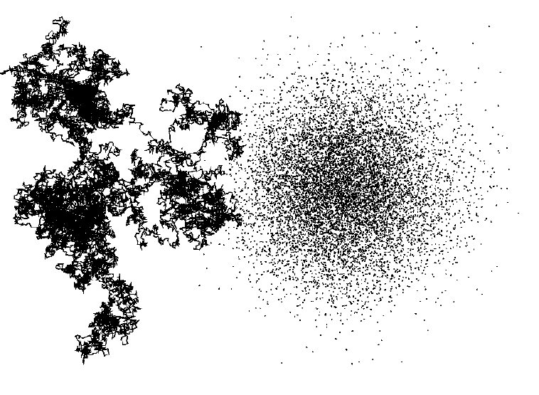

random walk

## 扩散方程：时间一阶导 ∝ 空间二阶导

物理量分布的时间一阶导数正比于空间二阶导数，比例系数定义为**扩散系数**：

$$\frac{\partial\rho}{\partial t} = \frac{\sigma^2}{2}\frac{\partial^2\rho}{\partial x^2} = D\frac{\partial^2\rho}{\partial x^2}$$

## 流量的一阶方程

定义流量 $J$，扩散方程可写为一阶的“通量 + 守恒”两式：

$$J = -D\frac{\partial\rho}{\partial x}, \qquad \frac{\partial\rho}{\partial t} = -\frac{\partial J}{\partial x}$$

- $J$：单位时间通过单位面积的物理量（通量）
- 负号：通量方向与梯度方向相反（由高浓度流向低浓度）

## 质量、动量、热量：同一套数学

| 传递量 | 定律（通量 = 系数 × 梯度） | 扩散系数 |
| --- | --- | --- |
| 质量 | Fick：$J = -D\nabla c$ | 质量扩散系数 $D$ |
| 动量 | 牛顿黏性：$\sigma_s = -\nu\nabla(\rho u)$ | 运动黏度 $\nu$ |
| 热量 | 傅里叶：$q = -\lambda\nabla T$ | 热扩散系数 $a$ |

$D$、$\nu$、$a$ 的单位**都是** $\text{m}^2/\text{s}$。

## 各自动态方程与广义输运方程

- 质量（Fick 定律）：$\dfrac{\partial c}{\partial t} = D\nabla^2 c$
- 动量（黏性扩散）：$\dfrac{\partial(\rho u)}{\partial t} = \nu\nabla^2(\rho u)$
- 热量（傅里叶定律）：$\dfrac{\partial u}{\partial t} = a\nabla^2 u$

对任意物理量 $\phi$，通用控制方程（含对流项 $\vec U$、扩散系数 $\Gamma_\phi$、源项 $S_\phi$）：

$$\frac{d}{dt}(\rho\phi) = \frac{\partial(\rho\phi)}{\partial t} + \nabla\cdot(\rho\vec U\phi) = \nabla\cdot(\Gamma_\phi\nabla\phi) + S_\phi$$

# 第二部分 · 傅里叶定律与热扩散方程

- Fourier 定律 $q=-\lambda\nabla T$
- 热扩散率 $a=\lambda/(\rho c)$
- 有热源时的传热方程
- PDE 分类与三类边界条件

## 从内能扩散到温度扩散

对内能（$u$）作热扩散，热流量（热流密度矢量）$q$：

$$q = -a\nabla u, \qquad \frac{\partial u}{\partial t} = -\nabla\cdot q = a\nabla^2 u$$

内能梯度转化为温度梯度（$\nabla u = \dfrac{\partial u}{\partial T}\nabla T = c_v\rho\,\nabla T$）：

$$q = -\lambda\nabla T$$

## 傅里叶定律

$$q = -\lambda\nabla T, \qquad q_x = -\lambda\frac{\partial T}{\partial x}$$

- $\lambda$：**导热系数**，单位 $\text{W}/(\text{m}\cdot\text{K})$
- 负号：热流方向与温度梯度（温度升高）方向相反
- 热流线处处垂直于等温面

## 热扩散方程与热扩散率

由内能方程除以 $c_v\rho$ 得温度方程：

$$\frac{\partial T}{\partial t} = \frac{\lambda}{c_v\rho}\nabla^2 T = a\nabla^2 T$$

**热扩散率**（导温系数）：

$$a = \frac{\lambda}{\rho c}$$

- $a$ 越大，物体内部温度“扯平”越快，温度变化传播越快
- $a$ 是材料传播温度变化能力大小的指标，单位 $\text{m}^2/\text{s}$

## 有热源时的传热方程

存在内热源 $\delta Q$ 时：

$$\frac{\partial u}{\partial t} = \lambda\nabla^2 T + \delta Q, \qquad \frac{\partial T}{\partial t} = \frac{\lambda}{c_v\rho}\nabla^2 T + \frac{\delta Q}{c_v\rho}$$

## 二阶 PDE 的类型（判别式）

一般二元二阶 PDE $a\phi_{xx}+b\phi_{xy}+c\phi_{yy}+\cdots = g$，判别式 $b^2-4ac$ 在坐标变换下不变：

- **双曲型**（$>0$）：波动方程 $\dfrac{\partial^2 u}{\partial t^2} = c^2\nabla^2 u$
- **抛物型**（$=0$）：传热方程 $\dfrac{\partial T}{\partial t} = D\nabla^2 T$
- **椭圆型**（$<0$）：泊松方程 $\nabla^2\phi = f$

## 定解条件：初始条件 + 边界条件

- **初始条件**：初始时刻温度分布 $T(x,0)=f(x)$
- 非稳态导热需初始条件 + 边界条件；稳态导热只需边界条件

三类边界条件：

1. **第一类（Dirichlet）**：规定边界温度 $T\big|_w = T_w$
2. **第二类（Neumann）**：规定边界热流密度 $-\lambda\dfrac{\partial T}{\partial n}\Big|_w = q_w$
3. **第三类（Robin）**：规定传热系数与环境温度 $-\lambda\dfrac{\partial T}{\partial n}\Big|_w = h(T_w - T_\infty)$

# 第三部分 · 稳态导热与热阻

- 平壁 / 圆筒壁 / 球壁三张参数卡
- 热阻串联与界面温度递推
- 临界热绝缘直径 $r_{\rm cr}=\lambda/h$
- 肋片与扩展表面

## 单层平壁导热

一维、稳态、无内热源，$\dfrac{d^2T}{dx^2}=0$，温度**线性分布**：

$$q = \frac{\lambda}{\delta}(T_1-T_2) = \frac{\Delta T}{\delta/\lambda}$$

- 热阻（面积热阻）：$R = \delta/\lambda$，单位 $\text{m}^2\cdot\text{K}/\text{W}$
- 类比欧姆定律：热流量 = 温压 / 热阻

## 多层平壁与热阻串联

各层接触良好、界面温度相等，稳态下各层热流量相同，热阻**串联相加**：

$$q = \frac{T_1 - T_{n+1}}{\displaystyle\sum_i \frac{\delta_i}{\lambda_i}} = \frac{\Delta T}{\sum_i R_i}$$

- 已知 $q$ 后，第 $i$ 层两侧壁温：$T_{i+1} = T_i - q R_i$

## 圆筒壁与球壁导热（与平壁对比）

| 壁面 | 温度分布 | 热流量 |
| --- | --- | --- |
| 平壁 | 线性 $T=C_1 r+C_2$ | $Q=\dfrac{\Delta T}{\sum \frac{\delta}{\lambda}}$（单位面积） |
| 圆筒壁 | 对数 $T=C_1\ln r+C_2$ | $Q=\dfrac{\Delta T}{\sum \frac{\ln(r_2/r_1)}{2\pi\lambda l}}$ |
| 球壁 | $1/r$ 分布 $T=C_1\frac{1}{r}+C_2$ | $Q=\dfrac{\Delta T}{\sum \frac{1/r_1-1/r_2}{4\pi\lambda}}$ |

## 平壁：完整参数卡（讲义 Table）

> 出处：讲义 `lec_5.tex` Table「不同壁面热传导相关公式」。**讲义笔误已改**：表中 $Q$ 行是单位面积口径（即热流密度），此处已注明。

| 参数 | 值 |
| --- | --- |
| 微分方程 | $-\dfrac{d}{dx}\left(-\lambda\dfrac{dT}{dx}\right)=0$（讲义统一用 $r$ 坐标，此处按常规用 $x$） |
| 通解形式 | $T=C_1x+C_2$；$\dfrac{T-T_1}{T_2-T_1}=\dfrac{x-x_1}{x_2-x_1}$（线性分布） |
| 热流密度 | $q=-\lambda\dfrac{\Delta T}{\Delta x}=-\dfrac{\Delta T}{\Delta x/\lambda}$ |
| 热流量（单位面积） | $q=\dfrac{\Delta T}{\sum\dfrac{\Delta x}{\lambda}}$（多层：热阻串联） |

- 温度分布是**直线**：面积不随 $x$ 变化 ⇒ 各截面热流量相同
- 面积热阻 $R=\delta/\lambda$（单位 $\text{m}^2\cdot\text{K/W}$），多层壁用 $T_{i+1}=T_i-qR_i$ 递推求界面温度

## 圆筒壁：完整参数卡（讲义 Table）

> 出处：讲义 `lec_5.tex` Table。半径 $r$ 处导热面积 $A=2\pi rl$ 随 $r$ 增大。

| 参数 | 值 |
| --- | --- |
| 微分方程 | $-\dfrac{d}{dr}\left(-(2\pi r)\lambda\dfrac{dT}{dr}\right)=0$ |
| 通解形式 | $T=C_1\ln r+C_2$；$\dfrac{T-T_1}{T_2-T_1}=\dfrac{\ln r-\ln r_1}{\ln r_2-\ln r_1}$（对数分布） |
| 热流密度（$r$ 处） | $q=-\dfrac{\lambda}{r}\dfrac{\Delta T}{\Delta\ln r}=-\dfrac{\Delta T}{\dfrac{\Delta\ln r}{\lambda/r}}$ |
| 热流量 | $Q=\dfrac{\Delta T}{\sum\dfrac{\Delta\ln r}{2\pi r l\cdot\lambda/r}}=\dfrac{\Delta T}{\sum\dfrac{\ln(r_2/r_1)}{2\pi\lambda l}}$ |

- 单层圆筒壁：$Q=\dfrac{2\pi\lambda l\,\Delta T}{\ln(r_2/r_1)}$（单位长度 $Q/l$ 是工程常用量）
- 热流密度 $q$ 随 $r$ 增大而减小（面积变大），**热流量 $Q$ 处处相同**

## 球壁：完整参数卡（讲义 Table）

> 出处：讲义 `lec_5.tex` Table。半径 $r$ 处导热面积 $A=4\pi r^2$。

| 参数 | 值 |
| --- | --- |
| 微分方程 | $-\dfrac{d}{dr}\left(-(4\pi r^{2})\lambda\dfrac{dT}{dr}\right)=0$ |
| 通解形式 | $T=C_1\dfrac{1}{r}+C_2$；$\dfrac{T-T_1}{T_2-T_1}=\dfrac{1/r-1/r_1}{1/r_2-1/r_1}$ |
| 热流密度（$r$ 处） | $q=-\dfrac{\lambda}{r^2}\dfrac{\Delta T}{\Delta(1/r)}=-\dfrac{\Delta T}{\dfrac{\Delta(1/r)}{\lambda/r^2}}$ |
| 热流量 | $Q=\dfrac{\Delta T}{\sum\dfrac{\Delta(1/r)}{4\pi r^2\cdot\lambda/r^2}}=\dfrac{\Delta T}{\sum\dfrac{1/r_1-1/r_2}{4\pi\lambda}}$ |

- 单层球壁：$Q=\dfrac{4\pi\lambda\,\Delta T}{1/r_1-1/r_2}$
- 三种壁面的差别 = “导热面积是否随半径变化”：平壁恒定 → 线性；圆筒 $\propto r$ → 对数；球 $\propto r^2$ → $1/r$

## 临界热绝缘直径

**问题**：管道外敷保温层，包得越厚就一定越隔热吗？

**圆筒壁 + 对流边界**的总热阻（单位长度）：

$$R_{\rm tot}=\frac{\ln(r_o/r_i)}{2\pi\lambda}+\frac{1}{2\pi r_o h}$$

- 保温层加厚（$r_o\uparrow$）：导热热阻 $\uparrow$，但外表面散热面积也 $\uparrow$（对流热阻 $\downarrow$）
- 令 $dR_{\rm tot}/dr_o=0$，得**临界绝缘半径**：

$$\boxed{\ r_{\rm cr}=\frac{\lambda}{h}\ }$$

**结论**：管道半径 $r_i<r_{\rm cr}$ 时，加保温层反而**增强散热**；$r_i>r_{\rm cr}$ 时保温才有效。

**数值例**：$\lambda=0.1$ W/(m·K)、$h=10$ W/(m²·K) ⇒ $r_{\rm cr}=0.01$ m = **10 mm**——细电线（半径 < 10 mm）包绝缘皮不是为了隔热，而是防触电。

**推导留给 AI**：① 让他对 $R_{\rm tot}$ 求导并解出 $r_{\rm cr}$；② 问：“电线绝缘层反而帮助散热”怎么解释（提示：半径小于临界值时表面积效应占优）。

## 肋片与扩展表面

**强化散热的手段**：在壁面上加**肋片**（翅片），增大散热面积。

- 原理：热量沿肋传导的同时，表面与流体对流换热——**导热 + 对流**的复合
- 温度沿肋高逐渐接近流体温度（肋根最热、肋端最冷）

**肋效率**（实际散热量 / 理想散热量，理想 = 全肋保持肋根温度）：

$$\eta_f=\frac{\tanh(mL)}{mL},\qquad m=\sqrt{\frac{hP}{\lambda A_c}}$$

- $h$：表面传热系数；$P$：肋截面周长；$A_c$：肋截面积；$L$：肋高
- $mL$ 大（导热差 / 对流强 / 肋高）⇒ 效率低

**工程判据**：$mL\lesssim1$ 时肋才划算（效率 > 0.76）；过高的肋”白长”。

**推导留给 AI**：① 让他写出等截面直肋的能量平衡并推出 $\tanh$ 解；② 问：“肋片材料该选 $\lambda$ 大还是小？”（提示：看 $m$ 的表达式。）

## 稳态导热思路小结

1. 写控制方程（常物性、稳态、无源：$\nabla^2T=0$）
2. 定解条件（几类边界 + 几何形状）
3. 积分得温度分布 → 由傅里叶定律得热流
4. 工程上：一维稳态问题直接套**热阻串联**

# 第四部分 · 非稳态导热简介

- $Bi$ 与 $Fo$ 数的物理含义
- 集总参数法（$Bi<0.1$）
- 时间常数与指数衰减
- 一维非稳态与海斯勒图

## 非稳态导热与 Bi、Fo 数

**非稳态导热**：温度场随时间变化（物体被加热/冷却的过程）。

两个核心无量纲数：

$$Bi=\frac{hL}{\lambda}=\frac{\text{内部导热热阻}}{\text{表面对流热阻}},\qquad Fo=\frac{a\tau}{L^2}=\frac{\text{无量纲时间}}{}$$

- $Bi$（毕渥数）：$h$ 表面传热系数、$L=V/A$ 特征长度、$\lambda$ 导热系数
- $Fo$（傅里叶数）：$a$ 热扩散率、$\tau$ 时间、$L$ 特征长度
- $Bi\ll1$：内部温度均匀（集总参数法）；$Bi$ 大：内部温差显著（必须解 PDE）
- $Fo>0.2$：级数解取首项即可（误差 < 1%）

**推导留给 AI**：① 问他 $Bi$ 为什么是”两个热阻之比”（提示：内部 $L/\lambda$、表面 $1/h$）；② 问 $Fo$ 的物理含义（提示：$\tau$ 与 $L^2/a$ 的比值，即”进行时间 / 扩散时间”）。

## 集总参数法

**适用条件**：$Bi=\dfrac{hL}{\lambda}<0.1$（内部导热远快于表面换热 ⇒ 物体内部温度近似均匀，$T=T(\tau)$）。

**能量平衡**：物体内能变化 = 表面对流散热量

$$\rho cV\frac{dT}{d\tau}=-hA(T-T_\infty)
\;\Longrightarrow\;
\frac{T-T_\infty}{T_0-T_\infty}=\exp\left(-\frac{hA}{\rho cV}\tau\right)$$

- **时间常数**：$\tau_c=\dfrac{\rho cV}{hA}$——温度差衰减到 $1/e$ 所需时间

**推导留给 AI**：① 让他从能量平衡分离变量解出指数律；② 问：“$\tau_c$ 小意味着什么”（提示：温度变化快）。

## 一维非稳态导热与海斯勒图

**半无限大固体**（一端温度突变，$t\to\infty$ 前另一端不受影响）：

$$\frac{T(x,\tau)-T_w}{T_0-T_w}=\mathrm{erf}\left(\frac{x}{2\sqrt{a\tau}}\right),\qquad \mathrm{erf}(z)=\frac{2}{\sqrt{\pi}}\int_0^z e^{-s^2}ds$$

- 特征穿透深度 $\sim\sqrt{a\tau}$：温度扰动传播距离 ∝ 时间的平方根
- 表面瞬时热流 $q_w=\lambda\dfrac{T_w-T_0}{\sqrt{\pi a\tau}}$（随时间衰减）

**有限厚度平板**：解是无穷级数，工程上用**海斯勒图**（Heisler chart）查：

$$\frac{\theta}{\theta_0}=\frac{T(x,\tau)-T_\infty}{T_0-T_\infty}=f\Big(Fo,\ Bi,\ \frac{x}{L}\Big)$$

- $Fo>0.2$ 时级数首项足够；多维物体（柱、方块）= 一维解**相乘**（乘积定理）

**推导留给 AI**：① 让他用拉普拉斯变换或相似变量法推出误差函数解（$\eta=x/2\sqrt{a\tau}$）；② 问：“$\sqrt{a\tau}$ 的量纲是什么，物理含义是什么”。

# 第五部分 · 例题与真题

- 真题：三种传热方式、傅里叶定律
- 真题：三层 / 四层平壁
- 算例：蒸汽管道（圆筒壁）
- 算例：钢球淬火（集总参数）

## 真题 1：三种传热方式

**简答**：说明三种基本传热方式的传热机理，以及区别与联系。（2025—2026 学年 A 卷 / B 卷）

**参考答案**：

- **导热**：依靠分子热运动与碰撞传递，需介质接触
- **热对流**：依靠流体宏观运动携带热量
- **热辐射**：依靠电磁波传递，无需介质

三种方式可同时存在，实际传热常为复合过程。

## 真题 2：傅里叶定律

**简答**：写出傅里叶定律表达式，并注明各符号含义。（2025—2026 学年 B 卷 / 2024—2025 春 A 卷）

**参考答案**：

$$q = -\lambda\frac{dT}{dx}$$

- $q$：热流密度（$\text{W/m}^2$）；$\lambda$：导热系数；$\frac{dT}{dx}$：温度梯度
- 负号：热流方向与温度梯度方向相反

## 真题 3：三层平壁导热

**计算**：三层平壁稳态导热，壁温依次为 600、500、300、100 ℃，厚度依次为 100、160、160 mm，第一层 $\lambda_1=25\,\text{W/(m·℃)}$，求热流密度、另外两层导热系数和热阻。（2025—2026 学年 A 卷）

**参考答案**：

$$q = \frac{\Delta T_1}{\delta_1/\lambda_1} = \frac{100}{0.1/25} = 25\,000\,\text{W/m}^2$$

$$\lambda_2 = \lambda_3 = \frac{q\delta_2}{\Delta T_2} = \frac{25\,000\times0.16}{200} = 20\,\text{W/(m·℃)}$$

$$R_1 = 0.004,\ R_2 = R_3 = 0.008\ (\text{m}^2\cdot\text{℃/W})$$

## 真题 4：四层平壁导热

**计算**：四层平壁无接触热阻，高温侧 800 ℃，厚度 100/125/200/400 mm，导热系数 20/10/8/5 W/(m·℃)，低温侧 100 ℃，求热流密度。（2025—2026 学年 B 卷）

**参考答案**：

$$q = \frac{800-100}{\frac{0.1}{20}+\frac{0.125}{10}+\frac{0.2}{8}+\frac{0.4}{5}} = \frac{700}{0.005+0.0125+0.025+0.08} \approx 5714\,\text{W/m}^2$$

## 算例：蒸汽管道的热损失

**题**：外径 50 mm、内径 25 mm 的钢管（$\lambda=50$ W/(m·K)）输送蒸汽，内壁 300 ℃、外壁 100 ℃，求**单位长度热损失**。

**解（Python 已复核）**：

$$\frac{Q}{l}=\frac{2\pi\lambda\,\Delta T}{\ln(r_2/r_1)}
=\frac{2\pi\times50\times200}{\ln(50/25)}
=\frac{62\,832}{0.693}
\approx90\,647\ \text{W/m}$$

- 注意用**对数平均**（不是算术平均半径）：$r_{\rm lm}=\dfrac{r_2-r_1}{\ln(r_2/r_1)}$
- 若换成**平壁公式**（取平均半径 $r_m=37.5$ mm）算：$Q/l=2\pi r_m\lambda\Delta T/\delta=\dfrac{2\pi\times0.0375\times50\times200}{0.025}=94\,248$ W/m，**偏大 4%**
- 管壁薄时平壁近似可用；壁越厚误差越大（教材第 8 章口径）

**推导留给 AI**：① 让他推导对数平均半径；② 问：“为什么平壁近似高估了热损失”。

## 算例：钢球淬火冷却时间

**题**：直径 50 mm 的钢球（$\lambda=40$ W/(m·K)、$\rho=7800$ kg/m³、$c=500$ J/(kg·K)），$h=20$ W/(m²·K)，从 500 ℃ 投入 30 ℃ 的油中，求冷却到 100 ℃ 所需时间。

**解（Python 已复核）**：

1. 先判据：$L_c=\dfrac{V}{A}=\dfrac{d}{6}=8.33$ mm，$Bi=\dfrac{hL_c}{\lambda}=0.0042<0.1$ ⇒ **集总参数法适用**
2. 时间常数 $\tau_c=\dfrac{\rho cV}{hA}=\dfrac{\rho c L_c}{h}=1625$ s
3. $\tau=-\tau_c\ln\dfrac{T-T_\infty}{T_0-T_\infty}=-1625\times\ln\dfrac{70}{470}=3094$ s ≈ **51.6 min**

**推导留给 AI**：① 让他复算（注意 V/A=d/6）；② 问：“若 $h$ 增大 10 倍，时间怎么变”（提示：$\tau_c\propto1/h$，时间缩到 1/10）。

# 第六部分 · 思考题、小结与作业

- 讲义思考题：黑体辐射（2 道）
- 作业：计算题 4 + 思考题 3
- 本讲小结：一条链与五个必记
- 下讲预告：对流换热

## 讲义思考题（lec_5 原题，2 道）

> 出处：讲义 `lec_5.tex`「思考题」段（第 233–253 行），为第 7 次课热辐射做铺垫。
1. **黑体的辐射能量密度**：没有相互作用的光子气体服从玻色–爱因斯坦分布，其辐射能量密度为

$$u_\nu(\nu,T)=\frac{8\pi h\nu^3}{c^3}\frac{1}{e^{h\nu/k_BT}-1},\qquad \text{单位}\ \text{J·m}^{-3}\cdot\text{Hz}^{-1}$$

2. **从能量密度到光谱辐射率**：$B_\nu\cdot4\pi=u_\nu\cdot c$，$B_\nu$ 单位 $\text{W·m}^{-2}\cdot\text{sr}^{-1}\cdot\text{Hz}^{-1}$。 若把 $u_\nu$（以频率为单位）改以**波长** $\lambda$ 为单位，如何得到 $B_\lambda$？与书中给出的 $C_1$、$C_2$ 常数比较。

**推导留给 AI**：① 第 1 题让他说明”光子气体为什么用玻色分布而不用费米分布”；② 第 2 题关键在换元 $u_\lambda d\lambda=u_\nu d\nu$（$\nu=c/\lambda$，$d\nu=-c d\lambda/\lambda^2$），让他推 $B_\lambda$ 并核对 $C_1=2hc^2$、$C_2=hc/k_B$。

## 作业（本讲）：计算题四道

> 各页”**推导留给 AI**”按当次讲到的部分布置 6–8 个小问；交自己的完整推导（PDF 文件名：学号－姓名－序号）。

## 作业（本讲·续）：思考题

**思考题（3 题）**

5. 为什么”热扩散率 $a$“与”导热系数 $\lambda$“是两个不同概念？各回答什么问题？
6. 为什么细电线包绝缘层不能隔热、反而有助于散热？（临界绝缘直径）
7. 第一、二、三类边界条件各举一个**日常**例子，并说明为什么必须这样设边界。

**推导留给 AI**：让他把你的 7 道题答案逐题挑错，重点看**单位**（mm→m、℃→K）与**判据**（$Bi$、稳态/非稳态）是否交代清楚。

## 本讲小结

**一条链**：

$$\underbrace{\text{随机行走}}_{\text{微观}}\ \to\ \underbrace{\text{扩散方程}}_{\text{数学}}\ \to\ \underbrace{q=-\lambda\nabla T}_{\text{本构}}\ \to\ \underbrace{\text{热阻网络}}_{\text{工程}}$$

**必记结论**：

1. 三种传热方式：导热（分子碰撞）、热对流（流体宏观运动）、热辐射（电磁波）
2. Fourier 定律 $q=-\lambda\nabla T$；热扩散率 $a=\lambda/(\rho c)$
3. 平壁热阻 $R=\delta/\lambda$；圆筒壁 $R=\ln(r_2/r_1)/(2\pi\lambda l)$；球壁 $R=(1/r_1-1/r_2)/(4\pi\lambda)$
4. 临界绝缘半径 $r_{\rm cr}=\lambda/h$；集总参数判据 $Bi<0.1$，时间常数 $\tau_c=\rho cV/(hA)$
5. 稳态导热：热阻串联，$Q=\Delta T/\sum R$；界面温度递推 $T_{i+1}=T_i-qR_i$

## 下讲预告

**第 6 次课 · 对流换热（第 10 章）**

- 牛顿冷却公式 $q=h(T_w-T_\infty)$ 与对流换热过程微分方程
- 流动边界层与热边界层
- 量纲分析与 Buckingham Π 定理：$Nu=f(Re,Pr)$
- 强制对流、自然对流的准则关联式
- 相似原理：模型实验如何代表实物

> 带上计算器；本讲的 Fourier 定律与边界层里的”贴壁导热”是下次课的出发点。